# Assignment10

Neelima Cherukuri

7/29/2022

Question 1: Confidence Interval: This kind of estimate is created by using the statistics of the observed data. It refers to the likelihood that a population parameter will fall inside a certain set of values or range of values (eg. the mean of a population). The confidence interval is created using confidence levels of typically 95 or 99 percent. Prediction Interval: A prediction interval, which is itself an estimation with a specific probability of an interval in which a future observation will fall, provides a range of values. Usually, these values are derived from information that has previously been collected. A prediction interval often forecasts the range in which a future observation will fall, whereas a confidence interval displays the expected range of values associated with some statistical feature of the data. These two intervals are so separate (eg.the mean of the population).

```r
library(openintro)
library(dplyr)
library(psych)
data("ncbirths")
```

Question 2:

The independent variable mature is seen to have a substantial positive correlation with the independent variable mage (0.64), so yes, I definitely notice some type of multicollinearity. Additionally, there is a significant positive correlation (0.71) between the variables mage and fage. Another illustration is the relationship between the variables prime and week, which appears to have a high negative correlation (-0.74). Weight and weeks have a positive connection of 0.67, whereas weight and lightbirthweight have a negative association of -0.72. Each fiedl’s fage’s distribution follows the normal distribution. Right-skewed distribution for mages not a regular distribution when mature the normal distribution for weeks visits that were not regularly delivered during the premie marital: A distribution that is not typical not often transmitted by habit Whitemom: Gains that are not usually distributed normal distribution of weight low birthweight: A deviation from the norm Not a typical distribution by gender

```r
str(ncbirths)
```

```
## tibble [1,000 × 13] (S3: tbl_df/tbl/data.frame)
##  $ fage          : int [1:1000] NA NA 19 21 NA NA 18 17 NA 20 ...
##  $ mage          : int [1:1000] 13 14 15 15 15 15 15 15 16 16 ...
##  $ mature        : Factor w/ 2 levels "mature mom","younger mom": 2 2 2 2 2 2 2 2 2 2 ...
##  $ weeks         : int [1:1000] 39 42 37 41 39 38 37 35 38 37 ...
##  $ premie        : Factor w/ 2 levels "full term","premie": 1 1 1 1 1 1 1 2 1 1 ...
##  $ visits        : int [1:1000] 10 15 11 6 9 19 12 5 9 13 ...
##  $ marital       : Factor w/ 2 levels "not married",..: 1 1 1 1 1 1 1 1 1 1 ...
##  $ gained        : int [1:1000] 38 20 38 34 27 22 76 15 NA 52 ...
##  $ weight        : num [1:1000] 7.63 7.88 6.63 8 6.38 5.38 8.44 4.69 8.81 6.94 ...
##  $ lowbirthweight: Factor w/ 2 levels "low","not low": 2 2 2 2 2 1 2 1 2 2 ...
##  $ gender        : Factor w/ 2 levels "female","male": 2 2 1 2 1 2 2 2 2 1 ...
##  $ habit         : Factor w/ 2 levels "nonsmoker","smoker": 1 1 1 1 1 1 1 1 1 1 ...
##  $ whitemom      : Factor w/ 2 levels "not white","white": 1 1 2 2 1 1 1 1 2 2 ...
```

```r
ncbirths_dataset <- as.data.frame(ncbirths)
class(ncbirths_dataset )
```

```
## [1] "data.frame"
```

```r
# Convert the character columns to numeric in order to impute the mean
new_ncbirths_dataset <- ncbirths_dataset %>%
  mutate_at(vars(fage,mage,weeks,visits,gained), ~as.numeric(as.character(.)))
# str(new_ncbirths_dataset)

# create my_mode function to impute mode for all the categorical variables in the dataset
 my_mode <- function (x, na.rm) {
  x_tab <- table(x)
  x_mode <- names(which(x_tab == max(x_tab)))
  if (length(x_mode) > 1) x_mode <- ">1 mode"
  return(x_mode)
}

 # For loop for imputing the mean and the mode for the NA values in the dataset
for (i in 1:ncol(new_ncbirths_dataset)) {
  if (class(new_ncbirths_dataset[,i])=="numeric") {
    new_ncbirths_dataset[is.na(new_ncbirths_dataset[,i]),i] <- mean(new_ncbirths_dataset[,i], na.rm = TRUE)
  } else if (class(new_ncbirths_dataset[,i]) =="factor") {
    new_ncbirths_dataset[is.na(new_ncbirths_dataset[,i]),i] <- my_mode(new_ncbirths_dataset[,i], na.rm = TRUE)
  }
}
str(new_ncbirths_dataset)
```

```
## 'data.frame':    1000 obs. of  13 variables:
##  $ fage          : num  30.3 30.3 19 21 30.3 ...
##  $ mage          : num  13 14 15 15 15 15 15 15 16 16 ...
##  $ mature        : Factor w/ 2 levels "mature mom","younger mom": 2 2 2 2 2 2 2 2 2 2 ...
##  $ weeks         : num  39 42 37 41 39 38 37 35 38 37 ...
##  $ premie        : Factor w/ 2 levels "full term","premie": 1 1 1 1 1 1 1 2 1 1 ...
##  $ visits        : num  10 15 11 6 9 19 12 5 9 13 ...
##  $ marital       : Factor w/ 2 levels "not married",..: 1 1 1 1 1 1 1 1 1 1 ...
##  $ gained        : num  38 20 38 34 27 ...
##  $ weight        : num  7.63 7.88 6.63 8 6.38 5.38 8.44 4.69 8.81 6.94 ...
##  $ lowbirthweight: Factor w/ 2 levels "low","not low": 2 2 2 2 2 1 2 1 2 2 ...
##  $ gender        : Factor w/ 2 levels "female","male": 2 2 1 2 1 2 2 2 2 1 ...
##  $ habit         : Factor w/ 2 levels "nonsmoker","smoker": 1 1 1 1 1 1 1 1 1 1 ...
##  $ whitemom      : Factor w/ 2 levels "not white","white": 1 1 2 2 1 1 1 1 2 2 ...
```

```r
 # Convert the levels to 0 and 1 for all the factor variables with two levels(1,2)
new_ncbirths_dataset$mature <-ifelse(new_ncbirths_dataset$mature == "younger mom", 0, 1)
new_ncbirths_dataset$premie <-ifelse(new_ncbirths_dataset$premie == "full term", 0, 1)
new_ncbirths_dataset$marital <-ifelse(new_ncbirths_dataset$marital == "married", 0, 1)
new_ncbirths_dataset$lowbirthweight <-ifelse(new_ncbirths_dataset$lowbirthweight == "not low", 0, 1)
new_ncbirths_dataset$gender <-ifelse(new_ncbirths_dataset$gender == "male", 0, 1)
new_ncbirths_dataset$habit <-ifelse(new_ncbirths_dataset$habit == "nonsmoker", 0, 1)
new_ncbirths_dataset$whitemom <-ifelse(new_ncbirths_dataset$whitemom == "not white", 0, 1)


# Build a full correlation matrix
cor(new_ncbirths_dataset[c("fage","mage","mature","weeks","premie","visits","marital", "gained", "weight","lowbirthweight","gender", "habit","whitemom")])
```

```
##                        fage         mage       mature       weeks       premie
## fage            1.000000000  0.705828921  0.473118312 -0.01444522  0.003098592
## mage            0.705828921  1.000000000  0.642034663 -0.03199522 -0.008521363
## mature          0.473118312  0.642034663  1.000000000 -0.04142545  0.022835690
## weeks          -0.014445225 -0.031995219 -0.041425446  1.00000000 -0.735429874
## premie          0.003098592 -0.008521363  0.022835690 -0.73542987  1.000000000
## visits          0.071025293  0.159712756  0.049580236  0.17132114 -0.144920467
## marital        -0.292565976 -0.438902713 -0.159319739 -0.06889859  0.087697646
## gained         -0.038375317 -0.059555130 -0.041534407  0.08919824 -0.130184908
## weight          0.062814219  0.055065889  0.006379432  0.66832129 -0.553766270
## lowbirthweight  0.002216790 -0.002050325  0.030345546 -0.58706496  0.559744636
## gender         -0.053751015  0.008695144  0.006484698 -0.01913430 -0.030394322
## habit          -0.073803204 -0.107232508 -0.051096988  0.01423928 -0.001275801
## whitemom        0.097857068  0.169253571  0.057285878  0.09852270 -0.079260891
##                     visits      marital      gained       weight lowbirthweight
## fage            0.07102529 -0.292565976 -0.03837532  0.062814219    0.002216790
## mage            0.15971276 -0.438902713 -0.05955513  0.055065889   -0.002050325
## mature          0.04958024 -0.159319739 -0.04153441  0.006379432    0.030345546
## weeks           0.17132114 -0.068898590  0.08919824  0.668321290   -0.587064958
## premie         -0.14492047  0.087697646 -0.13018491 -0.553766270    0.559744636
## visits          1.00000000 -0.228048088  0.05794153  0.132436678   -0.114334551
## marital        -0.22804809  1.000000000 -0.02451152 -0.157882424    0.118708584
## gained          0.05794153 -0.024511518  1.00000000  0.150268348   -0.100187168
## weight          0.13243668 -0.157882424  0.15026835  1.000000000   -0.718427419
## lowbirthweight -0.11433455  0.118708584 -0.10018717 -0.718427419    1.000000000
## gender          0.04007208  0.003459171 -0.03561029 -0.132158904    0.020163852
## habit          -0.07360498  0.107480815  0.04190576 -0.068548402    0.038505610
## whitemom        0.07510882 -0.329686420  0.07221896  0.159300572   -0.081014450
##                      gender        habit    whitemom
## fage           -0.053751015 -0.073803204  0.09785707
## mage            0.008695144 -0.107232508  0.16925357
## mature          0.006484698 -0.051096988  0.05728588
## weeks          -0.019134305  0.014239282  0.09852270
## premie         -0.030394322 -0.001275801 -0.07926089
## visits          0.040072077 -0.073604982  0.07510882
## marital         0.003459171  0.107480815 -0.32968642
## gained         -0.035610291  0.041905756  0.07221896
## weight         -0.132158904 -0.068548402  0.15930057
## lowbirthweight  0.020163852  0.038505610 -0.08101445
## gender          1.000000000 -0.038439819  0.03039061
## habit          -0.038439819  1.000000000  0.03865197
## whitemom        0.030390615  0.038651968  1.00000000
```

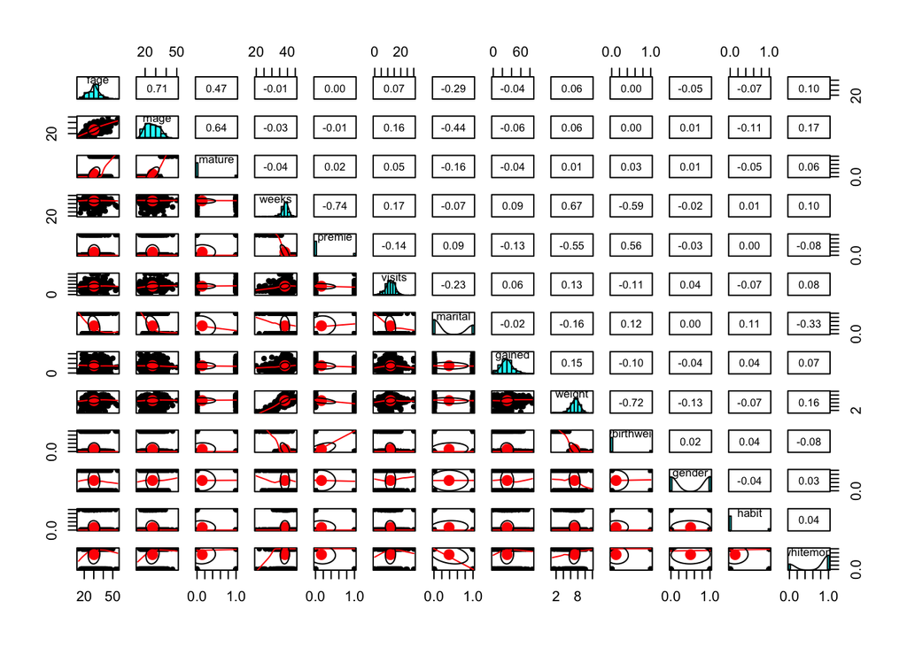

```r
# Plot the correlation matrix for better analysis
pairs.panels(new_ncbirths_dataset[c("fage","mage","mature","weeks","premie","visits","marital", "gained", "weight","lowbirthweight","gender", "habit","whitemom")])
```

Question 3 :

The Multiple R squared, which in this case is 64 percent (0.6409), is an indicator of how much variation in weight can be explained by the other factors (fage, mage, mature, weeks, premie, visits, marital, gained, lowbirthweight, gender, habit, and white mother), and it can be used to determine how reliable the predictions from the regression equation are.

The adjusted R2 score of 0.6365 is not terrible because it shows that the independent factors in the dataset account for roughly 63 percent of the variation in the dependent variable (weight) (fage, mage, mature, weeks, premie, visits, marital, gained, lowbirthweight, gender, habit ,whitemom). The modified R2 typically provides information about how well the model fits the dataset, and a result of 0.6 still denotes a respectable match. The standard error demonstrates the typical deviation of the observed data from the regression line. Additionally, it is crucial for determining the 95 percent confidence interval. The standard error of this model is 0.91. The linear regression model’s ability to fit the data more accurately than a model with no predictor variables is indicated by the F test statistic (intercept-mode only). Indicative of the fact that this linear regression model does offer a better fit to the data than a model with no predictor variables, the F statistic value for this model is 146.8, which is fairly high.The coefficients weeks, gained, lowbirthweight, gender, habit, and white mother all have a p-value of less than 0.05, making them all statistically significant.

```r
model_1 <- lm(weight ~ fage + mage + mature + weeks + premie + visits + marital + gained + lowbirthweight + gender + habit + whitemom, data = new_ncbirths_dataset)
# print(model_1)
summary(model_1)
```

```
##
## Call:
## lm(formula = weight ~ fage + mage + mature + weeks + premie +
##     visits + marital + gained + lowbirthweight + gender + habit +
##     whitemom, data = new_ncbirths_dataset)
##
## Residuals:
##     Min      1Q  Median      3Q     Max
## -2.4651 -0.6136 -0.0291  0.5544  3.9764
##
## Coefficients:
##                 Estimate Std. Error t value Pr(>|t|)
## (Intercept)    -0.493285   0.651534  -0.757 0.449163
## fage            0.008447   0.006643   1.272 0.203819
## mage            0.003819   0.008232   0.464 0.642772
## mature          0.010185   0.112485   0.091 0.927869
## weeks           0.192612   0.015452  12.465  < 2e-16 ***
## premie          0.009671   0.122595   0.079 0.937139
## visits         -0.002453   0.007677  -0.320 0.749367
## marital        -0.086911   0.071135  -1.222 0.222082
## gained          0.006912   0.002084   3.316 0.000945 ***
## lowbirthweight -2.309613   0.117097 -19.724  < 2e-16 ***
## gender         -0.347629   0.058071  -5.986    3e-09 ***
## habit          -0.264852   0.088036  -3.008 0.002692 **
## whitemom        0.233597   0.068287   3.421 0.000650 ***
## ---
## Signif. codes:  0 '***' 0.001 '**' 0.01 '*' 0.05 '.' 0.1 ' ' 1
##
## Residual standard error: 0.9097 on 987 degrees of freedom
## Multiple R-squared:  0.6409, Adjusted R-squared:  0.6365
## F-statistic: 146.8 on 12 and 987 DF,  p-value: < 2.2e-16
```

Question 4:

```r
# Build a multiple regression model in which all coefficients are significant.

model_2 <- lm(weight ~ fage + mage + mature + weeks + premie + visits + marital + gained + lowbirthweight + gender + habit + whitemom, data = new_ncbirths_dataset)

# model_2 results
summary(model_2)
```

```
##
## Call:
## lm(formula = weight ~ fage + mage + mature + weeks + premie +
##     visits + marital + gained + lowbirthweight + gender + habit +
##     whitemom, data = new_ncbirths_dataset)
##
## Residuals:
##     Min      1Q  Median      3Q     Max
## -2.4651 -0.6136 -0.0291  0.5544  3.9764
##
## Coefficients:
##                 Estimate Std. Error t value Pr(>|t|)
## (Intercept)    -0.493285   0.651534  -0.757 0.449163
## fage            0.008447   0.006643   1.272 0.203819
## mage            0.003819   0.008232   0.464 0.642772
## mature          0.010185   0.112485   0.091 0.927869
## weeks           0.192612   0.015452  12.465  < 2e-16 ***
## premie          0.009671   0.122595   0.079 0.937139
## visits         -0.002453   0.007677  -0.320 0.749367
## marital        -0.086911   0.071135  -1.222 0.222082
## gained          0.006912   0.002084   3.316 0.000945 ***
## lowbirthweight -2.309613   0.117097 -19.724  < 2e-16 ***
## gender         -0.347629   0.058071  -5.986    3e-09 ***
## habit          -0.264852   0.088036  -3.008 0.002692 **
## whitemom        0.233597   0.068287   3.421 0.000650 ***
## ---
## Signif. codes:  0 '***' 0.001 '**' 0.01 '*' 0.05 '.' 0.1 ' ' 1
##
## Residual standard error: 0.9097 on 987 degrees of freedom
## Multiple R-squared:  0.6409, Adjusted R-squared:  0.6365
## F-statistic: 146.8 on 12 and 987 DF,  p-value: < 2.2e-16
```

```r
# step by step remove the coefficients with a p-value > 0.05
# Step 1 - Remove the  coefficient premie from model_2 beacuse it has the highest p-value (0.937139).
model_2_step1 <- lm(weight ~ fage + mage + mature + weeks + visits + marital + gained + lowbirthweight + gender + habit + whitemom, data = new_ncbirths_dataset)

# model_2_step1 results
summary(model_2_step1)
```

```
##
## Call:
## lm(formula = weight ~ fage + mage + mature + weeks + visits +
##     marital + gained + lowbirthweight + gender + habit + whitemom,
##     data = new_ncbirths_dataset)
##
## Residuals:
##     Min      1Q  Median      3Q     Max
## -2.4624 -0.6153 -0.0275  0.5553  3.9756
##
## Coefficients:
##                 Estimate Std. Error t value Pr(>|t|)
## (Intercept)    -0.462866   0.524905  -0.882 0.378095
## fage            0.008459   0.006638   1.274 0.202845
## mage            0.003790   0.008220   0.461 0.644807
## mature          0.010325   0.112414   0.092 0.926838
## weeks           0.191876   0.012313  15.584  < 2e-16 ***
## visits         -0.002457   0.007672  -0.320 0.748854
## marital        -0.086838   0.071093  -1.221 0.222201
## gained          0.006898   0.002075   3.324 0.000919 ***
## lowbirthweight -2.307519   0.113991 -20.243  < 2e-16 ***
## gender         -0.347956   0.057893  -6.010  2.6e-09 ***
## habit          -0.264897   0.087990  -3.011 0.002674 **
## whitemom        0.233695   0.068241   3.425 0.000641 ***
## ---
## Signif. codes:  0 '***' 0.001 '**' 0.01 '*' 0.05 '.' 0.1 ' ' 1
##
## Residual standard error: 0.9093 on 988 degrees of freedom
## Multiple R-squared:  0.6408, Adjusted R-squared:  0.6369
## F-statistic: 160.3 on 11 and 988 DF,  p-value: < 2.2e-16
```